# Monte Carlo Simulation Error

Xiaohe (Marina) Yue

# SIMULATION

- Large-scale computer-based simulations is a method of producing quantitative and predictive information. It is better that simulation results can come with a high confidence level.
- For doing simulation, we could generate randoms from unknown distribution and then repeat the simulation multiple times. Results will not be the same for each time.
- For repeating the simulation process, each time the outputs are not the same. Simulations involve their attendant errors, and these error models can be used to improve the prediction.
- Some of the reasons for simulation errors: inaccurate input data, inaccurate physics models, and limited accuracy of the solutions of the governing equations.
- There are two types of error. Absolute Error refers to the mathematical difference between the estimated probability (P`) and the actual probability (P). Relative Error divides the absolute error by the actual probability.

#### ABSOLUTE ERROR

- Absolute error is the difference between the measured value and “true” value.
- This can be caused by your scale not measuring the exact amount you are trying to measure.
- Absolute error = |P` - P|

#### RELATIVE ERROR

- When used as a measure of precision, it is the ratio of the absolute error of a measurement to the measurement being taken.
- It can describe accuracy on how a measurement is compared to the true value.
- Relative error = |P` - P| / P

# Example

Here we perform a 14 X 5 factorial experiment simulation that estimates the error for each combination of replicate number (2^2, 2^3, …, 2^15) and probability (0.01, 0.05, 0.10, 0.25, 0.50). Let p hat denote the probability estimated from simulation, and let p denote the true underlying probability.

The main idea is to create a matrix that can store all the mean number of the absolute error/ relative error from each sample size, and then we can make a plot for these mean numbers.

### Simulation error in Log2 scale

```r
n <- rep(NA,14)
for(i in 1:14){
  n[i] <-2^(i+1)
}
M <- matrix(NA,14,5)
p <- c(0.01, 0.05, 0.10, 0.25, 0.50)
for(x in 1:length(p)){
  for(y in 1:length(n)){
    TestSample <- rep(NA,100000)
    for(z in 1:100000){
      TestSample[z] <- abs(rbinom(1, n[y],p[x])/n[y]-p[x])
    }
    M[y,x]<- mean(TestSample)
  }
M
}
```

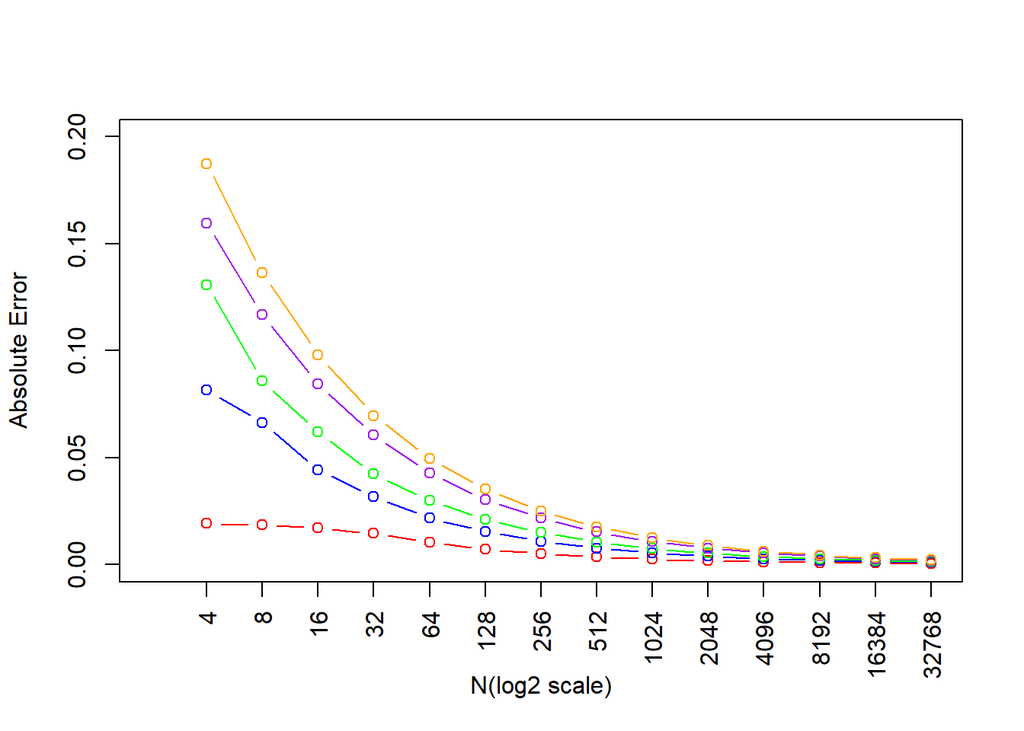

```r
plot(M[,1], xlim = c(0,14),ylim = c(0,0.2),xaxt="n",xlab = "N(log2 scale)",ylab="Absolute Error")
lname <- p
xname <- n
axis(1, at=1:14,las=2,lab=xname)
lines(M[,1],col="red",type = "b")
lines(M[,2],col="blue",type = "b")
lines(M[,3],col="green",type = "b")
lines(M[,4],col="purple",type = "b")
lines(M[,5],col="orange",type = "b")
```

```r
n <- rep(NA,14)
for(i in 1:14){
  n[i] <-2^(i+1)
}
MR <- matrix(NA,14,5)
p <- c(0.01, 0.05, 0.10, 0.25, 0.50)
for(x in 1:length(p)){
  for(y in 1:length(n)){
    TestSample <- rep(NA,100000)
    for(z in 1:100000){
      TestSample[z] <- abs(rbinom(1, n[y],p[x])/n[y]-p[x])/p[x]
    }
    MR[y,x]<- mean(TestSample)
  }

}
```

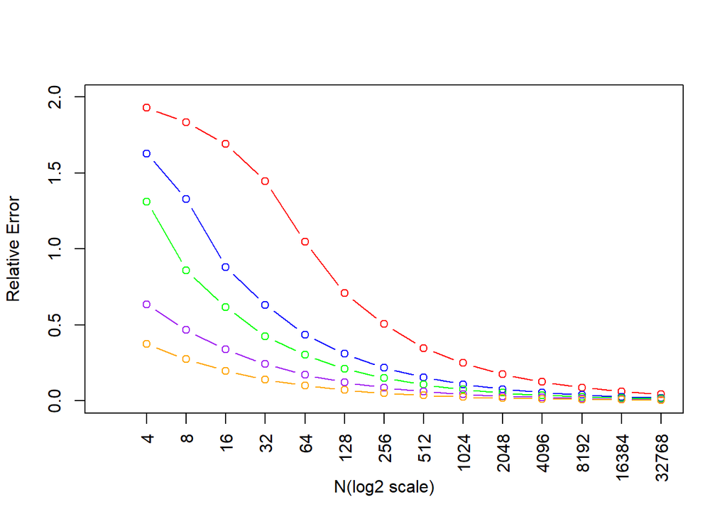

```r
plot(MR[,1], xlim = c(0,14),ylim = c(0,2.0),xaxt="n",xlab = "N(log2 scale)",ylab="Relative Error")
lname <- p
xname <- n
axis(1, at=1:14,las=2,lab=xname)

lines(MR[,1],col="red",type = "b")
lines(MR[,2],col="blue",type = "b")
lines(MR[,3],col="green",type = "b")
lines(MR[,4],col="purple",type = "b")
lines(MR[,5],col="orange",type = "b")
```

### Simulation error with y-axis in Log10 scale

Then, we try to generate the results with the y-axis on the log10 scale.

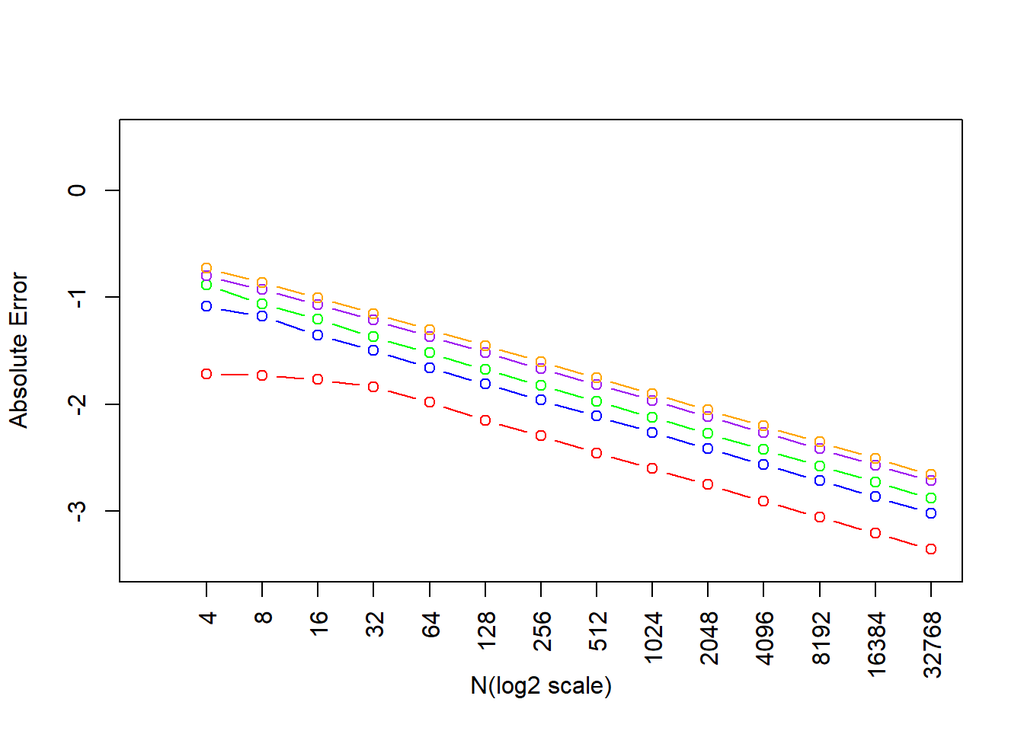

```r
n <- rep(NA,14)
for(i in 1:14){
  n[i] <-2^(i+1)
}
M10 <- matrix(NA,14,5)
p <- c(0.01, 0.05, 0.10, 0.25, 0.50)
for(x in 1:length(p)){
  for(y in 1:length(n)){
    TestSample <- rep(NA,100000)
    for(z in 1:100000){
      TestSample[z] <- abs(rbinom(1, n[y],p[x])/n[y]-p[x])
    }
    M10[y,x]<- log10(mean(TestSample))
  }

}

plot(M10[,1], xlim = c(0,14),ylim = c(-3.5,0.5),xaxt="n",xlab = "N(log2 scale)",ylab="Absolute Error")
lname <- p
xname <- n
axis(1, at=1:14,las=2,lab=xname)
lines(M10[,1],col="red",type = "b")
lines(M10[,2],col="blue",type = "b")
lines(M10[,3],col="green",type = "b")
lines(M10[,4],col="purple",type = "b")
lines(M10[,5],col="orange",type = "b")
```

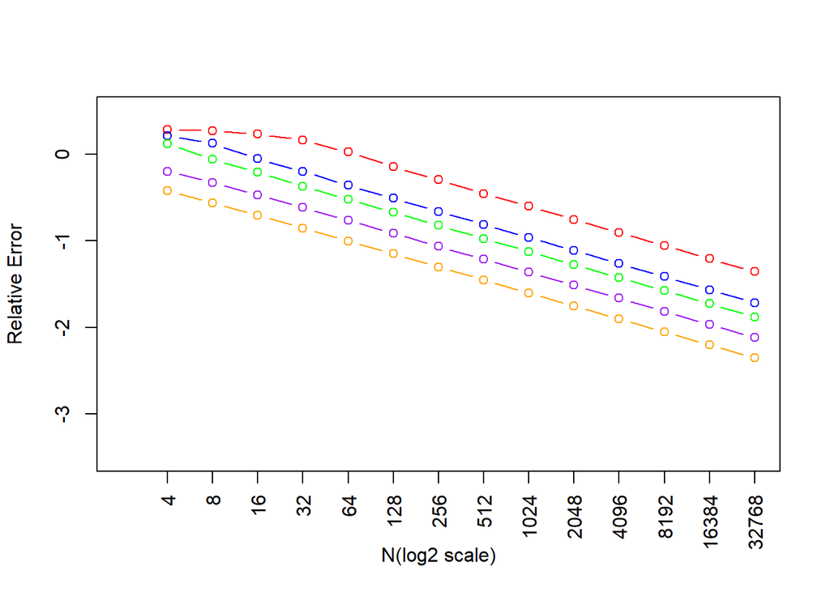

```r
n <- rep(NA,14)
for(i in 1:14){
  n[i] <-2^(i+1)
}
M10_R <- matrix(NA,14,5)
p <- c(0.01, 0.05, 0.10, 0.25, 0.50)
for(x in 1:length(p)){
  for(y in 1:length(n)){
    TestSample <- rep(NA,100000)
    for(z in 1:100000){
      TestSample[z] <- abs(rbinom(1, n[y],p[x])/n[y]-p[x])/p[x]
    }
    M10_R[y,x]<- log10(mean(TestSample))
  }

}

plot(M10_R[,1], xlim = c(0,14),ylim = c(-3.5,0.5),xaxt="n",xlab = "N(log2 scale)",ylab="Relative Error")
lname <- p
xname <- n
axis(1, at=1:14,las=2,lab=xname)
lines(M10_R[,1],col="red",type = "b")
lines(M10_R[,2],col="blue",type = "b")
lines(M10_R[,3],col="green",type = "b")
lines(M10_R[,4],col="purple",type = "b")
lines(M10_R[,5],col="orange",type = "b")
```

# Resources

For more information: * There are two main reasons to use logarithmic scales in charts and graphs. The first is to respond to skewness towards large values; the data values are spread out better with the logarithmic scale. The second is to show percent change or multiplicative factors. * Check more info on https://www.forbes.com/sites/naomirobbins/2012/01/19/when-should-i-use-logarithmic-scales-in-my-charts-and-graphs/#344eb6715e67